# Housing Loans

Author

Danyili Hong

```r
hdma_mi_20 <-
  read_csv('https://sldr.netlify.app/data/hdma-mi-20.csv') |>
  mutate(
    derived_race = case_when(
      derived_race == 'White' ~ 'White',
      derived_race == 'Black or African American' ~ 'Black or African American',
      derived_race == 'Asian' ~ 'Asian',
      derived_race == 'Race Not Available' ~ 'Race Not Available',
      TRUE ~ 'Other'
    ),
    loan_to_value_ratio = parse_number(loan_to_value_ratio),
    property_value = parse_number(property_value),
    co_applicant = ifelse(`co-applicant_ethnicity-1` == 5, 'No', 'Yes'),
    loan_term = parse_number(loan_term),
    aus = `aus-1`
  )
# Limit to only Kent County (where Calvin is located), if desired
hdma_kent_20 <- hdma_mi_20 |>
  filter(county_code == 26081)
```

# Model Plan

## Causal Diagram

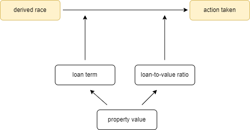

Considering the causal diagram above, the response variable will be the number of loan approvals and the main predictor I’m most interested in is different races of the borrowers. I want to see if loan-to-value ratio and loan term will affect the probability of approving so I put both loan-to-value ratio and loan term as my moderators. Property could also affect loan-to-value ratio and loan term in some ways. Since it’s binary data, we are going to use binomial family and logit link function.

```r
hdma_kent_20 <- hdma_kent_20 |>
  # for case_when, each variable value gets a line of the form
  #  logical_condition_statement ~ new_value_to_assign
  mutate(action_taken = case_when(action_taken == 1 ~ 'Loan granted',
                                  action_taken == 3 ~ 'Loan denied'),
         action_taken = factor(action_taken))

mosaic::tally(~action_taken, data = hdma_kent_20)
```

```
action_taken
 Loan denied Loan granted
         456         8777
```

```r
hdma_kent_20 <- hdma_kent_20 |> mutate(income = income / 100000)
hdma_kent_20 <- hdma_kent_20 |> mutate(property_value = property_value / 100000)
```

# Exploration

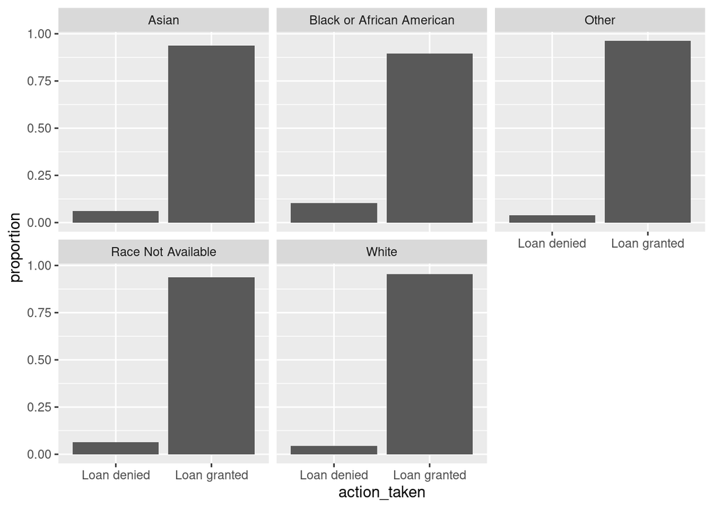

```r
gf_props(~action_taken| derived_race,
         data = hdma_kent_20)
```

```r
mosaic::tally(~derived_race, data = hdma_kent_20)
```

```
derived_race
                    Asian Black or African American                     Other
                      276                       249                       186
       Race Not Available                     White
                     1410                      7112
```

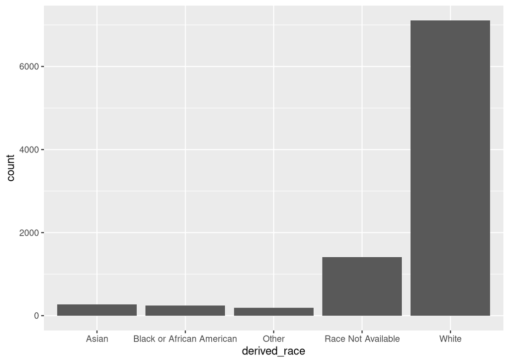

```r
hdma_kent_20 <- hdma_kent_20 |>
  mutate(drived_race = fct_lump_min(derived_race, min = 200))
gf_bar(~derived_race, data = hdma_kent_20)
```

It’s not very obvious but we can see that Asian, Black or African American, and Race not Available are slightly more likely to get denied on their application.

# Fit the model

```r
model <- glmmTMB(action_taken ~ derived_race + loan_term + loan_to_value_ratio + property_value,
                 data = hdma_kent_20,
                 family = binomial(link = 'logit'))
summary(model)
```

```
 Family: binomial  ( logit )
Formula:
action_taken ~ derived_race + loan_term + loan_to_value_ratio +
    property_value
Data: hdma_kent_20

     AIC      BIC   logLik deviance df.resid
  3317.0   3373.7  -1650.5   3301.0     8863


Conditional model:
                                        Estimate Std. Error z value Pr(>|z|)
(Intercept)                            3.052e+00  5.064e-01   6.027 1.67e-09
derived_raceBlack or African American -4.455e-01  3.289e-01  -1.354   0.1756
derived_raceOther                      8.656e-01  5.184e-01   1.670   0.0950
derived_raceRace Not Available         5.883e-02  2.758e-01   0.213   0.8311
derived_raceWhite                      4.370e-01  2.580e-01   1.694   0.0903
loan_term                             -6.604e-05  9.880e-04  -0.067   0.9467
loan_to_value_ratio                   -6.186e-03  4.169e-03  -1.484   0.1379
property_value                         7.190e-02  3.608e-02   1.993   0.0463

(Intercept)                           ***
derived_raceBlack or African American
derived_raceOther                     .
derived_raceRace Not Available
derived_raceWhite                     .
loan_term
loan_to_value_ratio
property_value                        *
---
Signif. codes:  0 '***' 0.001 '**' 0.01 '*' 0.05 '.' 0.1 ' ' 1
```

# Assessment

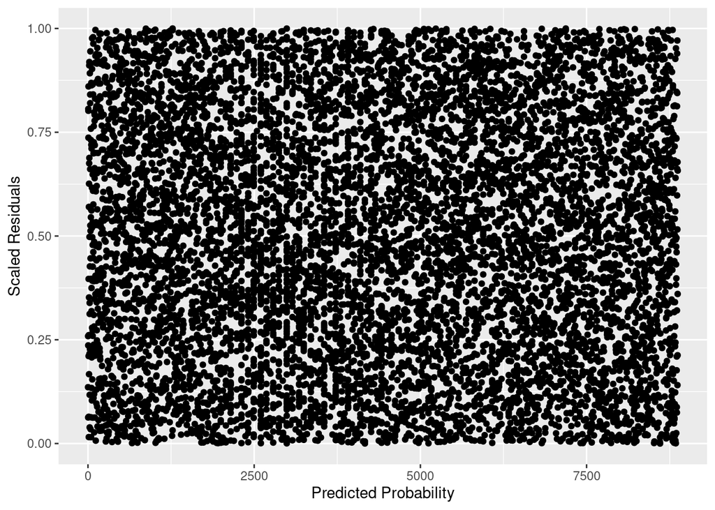

```r
model_sim <- simulateResiduals(model)

gf_point(model_sim$scaledResiduals ~ rank(fitted(model))) |>
  gf_labs(x = 'Predicted Probability',
          y = 'Scaled Residuals')
```

The points are spread uniformly top-to-bottom so we have no indication that the mean-variance relationship departs from what is expected.If you zoom in to the graph you can see a pattern that most of the dots is in same vertical direction around x = 2500 area, I don’t know if it has enough evidence to show the linear trend.

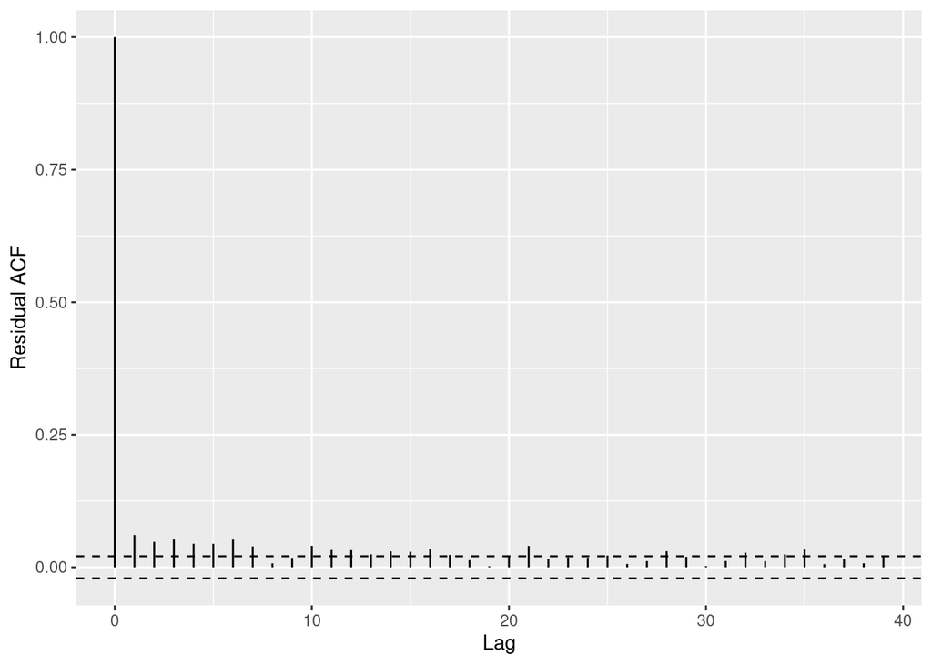

```r
s245::gf_acf(~resid(model))
```

# Conclusions

## Model Selection

```r
car::Anova(model)
```

```
Analysis of Deviance Table (Type II Wald chisquare tests)

Response: action_taken
                      Chisq Df Pr(>Chisq)
derived_race        24.7710  4  5.593e-05 ***
loan_term            0.0045  1    0.94671
loan_to_value_ratio  2.2013  1    0.13789
property_value       3.9716  1    0.04627 *
---
Signif. codes:  0 '***' 0.001 '**' 0.01 '*' 0.05 '.' 0.1 ' ' 1
```

## Prediction Plot

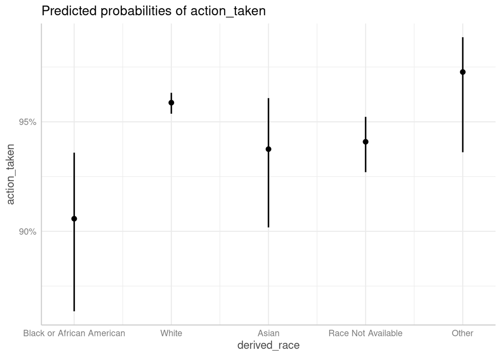

```r
ggpredict(model, terms = 'derived_race') |>
  plot()
```